# Question 1: Yield Spread

TC Baltazar (19776209)

December 2021

## 0.1 Introduction

Bond yields are an important economic indicator, and can be seen as a sign of investor sentiment about the economy. Interest rates and bond yields have a positive relationship, and, to a large extent, lower yields on Advanced Economy bonds can lead investors to search for yield elsewhere. This means that when there is a “risk-on” sentiment in global markets, and investors shift more capital into Emerging Markets, this greater demand for bonds should drive up their prices and, by extension, decrease the yield to investors. This sections of the README aims to investigate trends in yield spreads using the data provided.

## 0.2 Data

The data sourced includes information on bond yields for SA (SA_bonds), as well as a wide basket of Advanced and Emerging economies (bonds_2y and bonds_10y). Data on the USD:ZAR spot rate is provided in “usdzar”, VIX is a composite volatility index including indicators for the US, EU, and EME’s. ZA_Infl contains historical inflation rates for SA, and BE_Infl is Break-Even Inflation, which gives an insight into the market’s pricing of future inflation. Finally, ZAR_IY is the 6-month forward implied yield for SA.

## 0.3 Exploratory Analysis

Calculating bond spreads was done using the formula: $Spread=Yield_{10Yr}-Yield_{2Yr}$

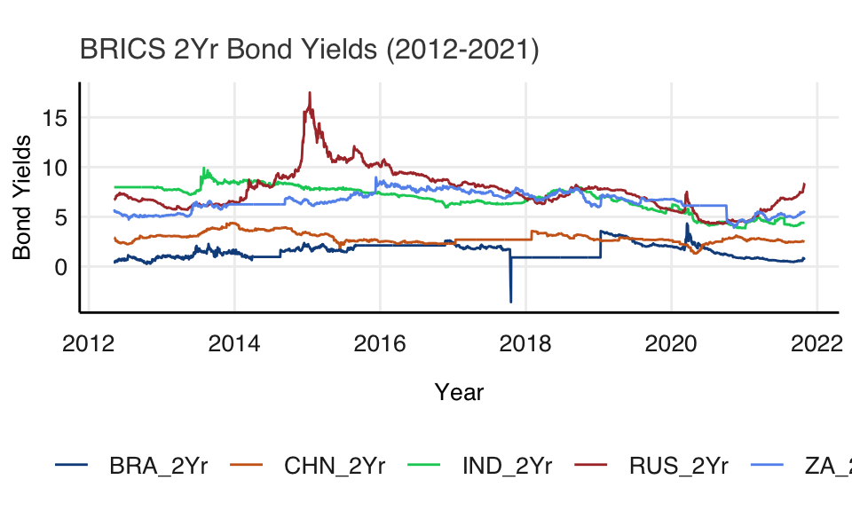

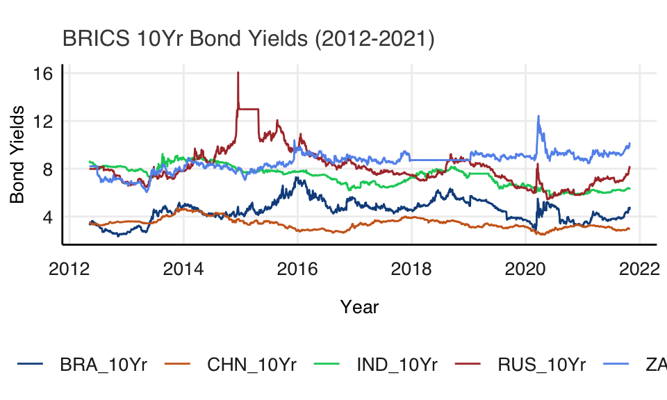

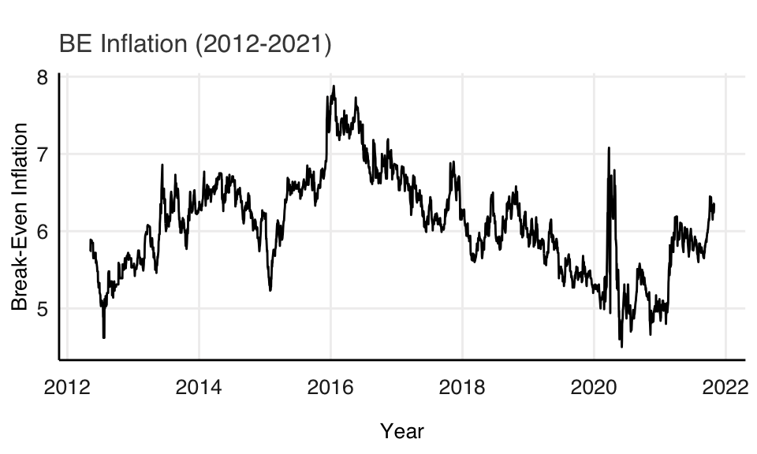

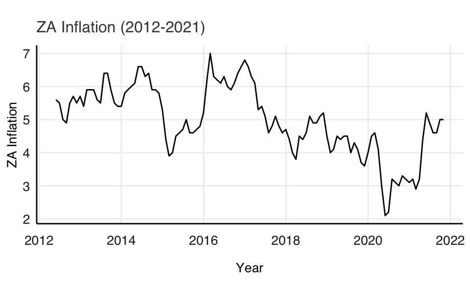

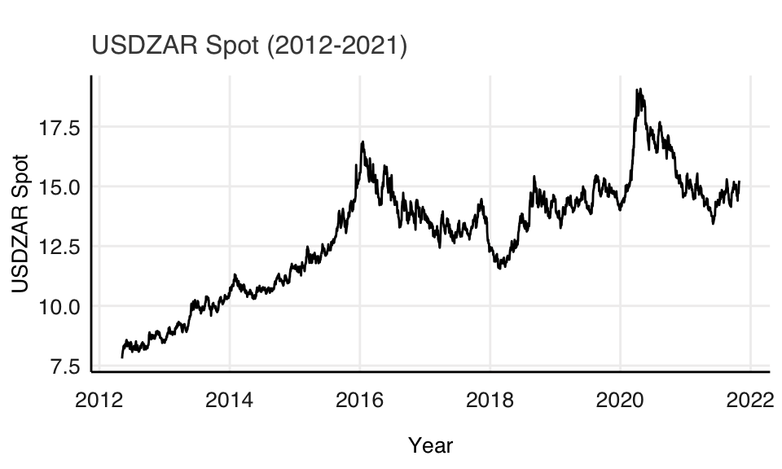

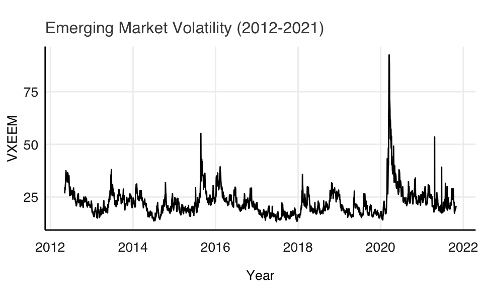

### 0.3.1 Descriptive Statistics

Tables 1-8 below provide descriptive statistics for the relevant variables.

Table 1: Summary Statistics: SA Bonds (Full Sample)

|  | ZA_3M | ZA_10Yr | ZA_2Yr |
| --- | --- | --- | --- |
| nbr.val | 5715.00 | 5715.00 | 5715.00 |
| nbr.null | 0.00 | 0.00 | 0.00 |
| nbr.na | 0.00 | 0.00 | 0.00 |
| min | 3.33 | 6.03 | 3.90 |
| max | 13.60 | 15.27 | 12.95 |
| range | 10.27 | 9.24 | 9.04 |
| sum | 43740.68 | 52162.85 | 44320.87 |
| median | 7.14 | 8.72 | 7.25 |
| mean | 7.65 | 9.13 | 7.76 |
| SE.mean | 0.03 | 0.02 | 0.02 |
| CI.mean.0.95 | 0.06 | 0.04 | 0.05 |
| var | 5.81 | 2.44 | 3.45 |
| std.dev | 2.41 | 1.56 | 1.86 |
| coef.var | 0.31 | 0.17 | 0.24 |

Table 2: Summary Statistics: SA Bonds (Reduced Sample)

|  | ZA_3M | ZA_10Yr | ZA_2Yr |
| --- | --- | --- | --- |
| nbr.val | 2475.00 | 2475.00 | 2475.00 |
| nbr.null | 0.00 | 0.00 | 0.00 |
| nbr.na | 0.00 | 0.00 | 0.00 |
| min | 3.33 | 6.03 | 3.90 |
| max | 7.38 | 12.42 | 8.97 |
| range | 4.04 | 6.39 | 5.07 |
| sum | 14778.77 | 21180.26 | 16048.68 |
| median | 6.14 | 8.72 | 6.52 |
| mean | 5.97 | 8.56 | 6.48 |
| SE.mean | 0.03 | 0.02 | 0.02 |
| CI.mean.0.95 | 0.05 | 0.03 | 0.04 |
| var | 1.56 | 0.64 | 0.98 |
| std.dev | 1.25 | 0.80 | 0.99 |
| coef.var | 0.21 | 0.09 | 0.15 |

Table 3: Summary Statistics: BE Inflation

|  | SAGGBE10 |
| --- | --- |
| nbr.val | 2475.00 |
| nbr.null | 0.00 |
| nbr.na | 0.00 |
| min | 4.50 |
| max | 7.88 |
| range | 3.38 |
| sum | 15061.74 |
| median | 6.09 |
| mean | 6.09 |
| SE.mean | 0.01 |
| CI.mean.0.95 | 0.02 |
| var | 0.39 |
| std.dev | 0.63 |
| coef.var | 0.10 |

Table 4: Summary Statistics: BRIC 2yr Bonds

|  | Brazil | CHINA | India | Russia |
| --- | --- | --- | --- | --- |
| nbr.val | 2475.00 | 2475.00 | 2475.00 | 2475.00 |
| nbr.null | 0.00 | 0.00 | 0.00 | 0.00 |
| nbr.na | 0.00 | 0.00 | 0.00 | 0.00 |
| min | -3.58 | 1.31 | 3.85 | 4.30 |
| max | 4.32 | 4.38 | 9.93 | 17.50 |
| range | 7.90 | 3.07 | 6.08 | 13.20 |
| sum | 3760.55 | 7080.74 | 16862.42 | 18880.28 |
| median | 1.55 | 2.70 | 7.08 | 7.28 |
| mean | 1.52 | 2.86 | 6.81 | 7.63 |
| SE.mean | 0.01 | 0.01 | 0.03 | 0.04 |
| CI.mean.0.95 | 0.03 | 0.02 | 0.05 | 0.08 |
| var | 0.50 | 0.25 | 1.80 | 4.37 |
| std.dev | 0.71 | 0.50 | 1.34 | 2.09 |
| coef.var | 0.47 | 0.18 | 0.20 | 0.27 |

Table 5: Summary Statistics: BRIC 10yr Bonds

|  | Brazil | CHINA | India | Russia |
| --- | --- | --- | --- | --- |
| nbr.val | 3017.00 | 4165.00 | 5948.00 | 3016.00 |
| nbr.null | 0.00 | 0.00 | 0.00 | 0.00 |
| nbr.na | 2931.00 | 1783.00 | 0.00 | 2932.00 |
| min | 2.33 | 2.47 | 4.95 | 5.43 |
| max | 7.29 | 4.71 | 12.23 | 16.06 |
| range | 4.96 | 2.24 | 7.28 | 10.63 |
| sum | 13358.30 | 14536.20 | 46100.40 | 24359.46 |
| median | 4.44 | 3.43 | 7.66 | 7.88 |
| mean | 4.43 | 3.49 | 7.75 | 8.08 |
| SE.mean | 0.02 | 0.01 | 0.02 | 0.03 |
| CI.mean.0.95 | 0.03 | 0.01 | 0.04 | 0.05 |
| var | 0.75 | 0.21 | 2.27 | 2.11 |
| std.dev | 0.87 | 0.46 | 1.51 | 1.45 |
| coef.var | 0.20 | 0.13 | 0.19 | 0.18 |

Table 6: Summary Statistics: USDZAR Spot

|  | SouthAfrica_Cncy |
| --- | --- |
| nbr.val | 8305.00 |
| nbr.null | 0.00 |
| nbr.na | 0.00 |
| min | 2.50 |
| max | 19.08 |
| range | 16.59 |
| sum | 66913.44 |
| median | 7.28 |
| mean | 8.06 |
| SE.mean | 0.04 |
| CI.mean.0.95 | 0.08 |
| var | 15.45 |
| std.dev | 3.93 |
| coef.var | 0.49 |

Table 7: Summary Statistics: ZA Inflation

|  | ZAR_Infl |
| --- | --- |
| nbr.val | 114.00 |
| nbr.null | 0.00 |
| nbr.na | 0.00 |
| min | 2.10 |
| max | 7.00 |
| range | 4.90 |
| sum | 567.00 |
| median | 5.00 |
| mean | 4.97 |
| SE.mean | 0.10 |
| CI.mean.0.95 | 0.19 |
| var | 1.10 |
| std.dev | 1.05 |
| coef.var | 0.21 |

Table 8: Summary Statistics: VIX (Emerging Markets)

|  | VXEEM |
| --- | --- |
| nbr.val | 2475.00 |
| nbr.null | 0.00 |
| nbr.na | 0.00 |
| min | 13.28 |
| max | 92.46 |
| range | 79.18 |
| sum | 55177.27 |
| median | 21.16 |
| mean | 22.29 |
| SE.mean | 0.13 |
| CI.mean.0.95 | 0.25 |
| var | 41.09 |
| std.dev | 6.41 |
| coef.var | 0.29 |

For the VIX data, only EME volatility was considered, and for the bond yields (2 and 10 year), the sample was restricted to only consider the BRIC economies. For the remainder of this discussion, focus will be on the domestic (South African) economy.

## 0.4 Correlation Analysis

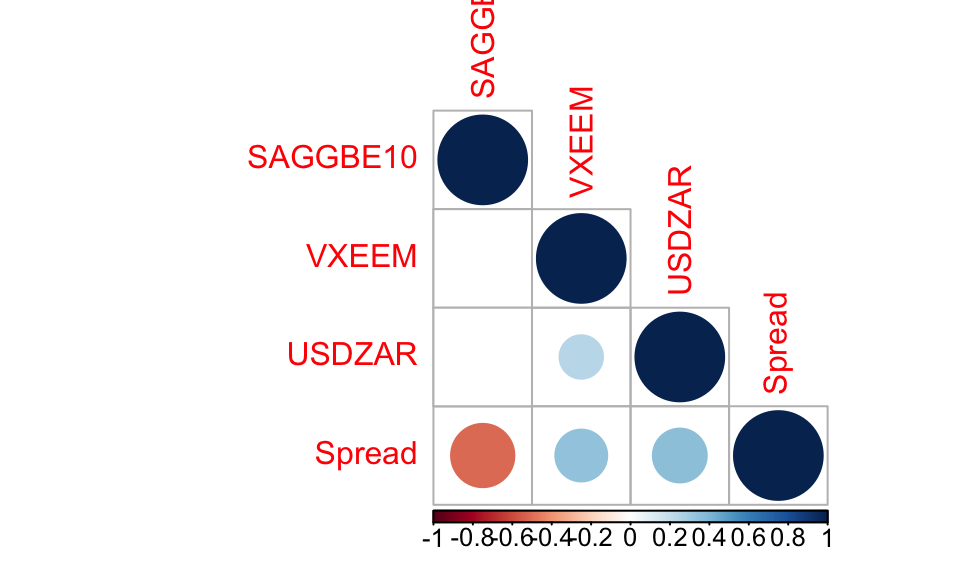

The yield spread on SA bonds is therefore positively related to the EM volatility index (0.342602, p-value=4.1763533^{-69}), the USDZAR spot rate (0.3693363, p-value=7.6125429^{-81}), and negatively related to the Break-Even inflation measure (-0.5098304, p-value=7.1673854^{-164}). The stronger US dollar vis-a-vis the Rand, and the greater perceived ‘risk’ in EM’s (measured by the VXEEM index) since the onset of the COVID-19 pandemic, can therefore be seen as two potential causes of the significantly higher yield spreads seen in SA since 2020.